# Klasifikasi menggunakan KNN

KNN atau k-Nearest Neighbors adalah salah satu algoritma dasar untuk klasifikasi data. Sebagai sebuah algoritma klasifikasi, tentunya data sample sudah ada “flag” untuk menuntun proses klasifikasi terhadap data yang akan diklasifikasi.

## 1. Eksplorasi Data

Data yang digunakan adalah datasets yang telah tersedia yakni “iris”.

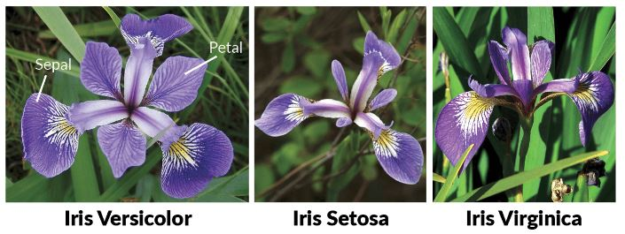

Gambar Bunga Iris

Bisa menggunakan data ke sumber :

http://archive.ics.uci.edu/ml/datasets/Iris

kemudian masuk ke data folder dan akses data menggunakan perintah ini.

|  | Sepal.Length | Sepal.Width | Petal.Length | Petal.Width | Species |
| --- | --- | --- | --- | --- | --- |
| 1 | 5.1 | 3.5 | 1.4 | 0.2 | Iris-setosa |
| 2 | 4.9 | 3.0 | 1.4 | 0.2 | Iris-setosa |
| 3 | 4.7 | 3.2 | 1.3 | 0.2 | Iris-setosa |
| 4 | 4.6 | 3.1 | 1.5 | 0.2 | Iris-setosa |
| 5 | 5.0 | 3.6 | 1.4 | 0.2 | Iris-setosa |
| 6 | 5.4 | 3.9 | 1.7 | 0.4 | Iris-setosa |

kali ini kita cukup menggunakan datasets saja karena sudah tersedia. Jika datasets belum ada, silahkan install menggunakan perintah kemudian eksplorasi data iris tersebut:

```r
str(irisdata)
```

```
'data.frame':   150 obs. of  5 variables:
 $ Sepal.Length: num  5.1 4.9 4.7 4.6 5 5.4 4.6 5 4.4 4.9 ...
 $ Sepal.Width : num  3.5 3 3.2 3.1 3.6 3.9 3.4 3.4 2.9 3.1 ...
 $ Petal.Length: num  1.4 1.4 1.3 1.5 1.4 1.7 1.4 1.5 1.4 1.5 ...
 $ Petal.Width : num  0.2 0.2 0.2 0.2 0.2 0.4 0.3 0.2 0.2 0.1 ...
 $ Species     : Factor w/ 3 levels "setosa","versicolor",..: 1 1 1 1 1 1 1 1 1 1 ...
```

```r
install.packages("ggvis")
```

```r
cor(irisdata$Petal.Length, irisdata$Petal.Width)
```

```
[1] 0.9628654
```

Bila di cek satu persatu.

```r
print(x[2])
```

```
[1] "versicolor"
```

```r
cor(irisdata[irisdata$Species == x[2], 1:4])
```

```
             Sepal.Length Sepal.Width Petal.Length Petal.Width
Sepal.Length    1.0000000   0.5259107    0.7540490   0.5464611
Sepal.Width     0.5259107   1.0000000    0.5605221   0.6639987
Petal.Length    0.7540490   0.5605221    1.0000000   0.7866681
Petal.Width     0.5464611   0.6639987    0.7866681   1.0000000
```

## 2. Persiapan Data

#### Normalisasi Data

Salah satu bagian dari persiapan data, selain dilakukan pembersihan data aoutlier, data mising, terkadang normalisasi juga diperlukan sebelum dilakukan proses pengolahan.

Ada dua bentuk normalisasi: * *example normalization* : normalisasi didasarkan pada masing-masing jenis (atribut) data, * *feature normalization* : normalisasi didasarkan pada keseluruhan data .

Kapan normalisasi diperlukan ? –> Apabila diduga data belum konsisten.

Misal, pada saat eksplorasi data, terlihat bahwa rentang antara nilai data minimum dan maksimum sangat besar, sehingga nantinya proses pengolahan bisa dipengaruhi / didominasi data berukuran besar tersebut. Misal, Data X rentang nilainya antara 1 sampai 1000, sedangkan data Y rentang nilainya antara 1 sampai 10, tentunya dalam pengolahannya, data X bisa mendominasi.

Seandainya data iris akan dinormalisasi, contoh proses normalisasi di bawah ini bisa digunakan.

```r
# Lihat hasilnya normalisasi`
summary(irisdata_norm)
```

```
  Sepal.Length     Sepal.Width      Petal.Length     Petal.Width
 Min.   :0.0000   Min.   :0.0000   Min.   :0.0000   Min.   :0.00000
 1st Qu.:0.2222   1st Qu.:0.3333   1st Qu.:0.1017   1st Qu.:0.08333
 Median :0.4167   Median :0.4167   Median :0.5678   Median :0.50000
 Mean   :0.4287   Mean   :0.4406   Mean   :0.4675   Mean   :0.45806
 3rd Qu.:0.5833   3rd Qu.:0.5417   3rd Qu.:0.6949   3rd Qu.:0.70833
 Max.   :1.0000   Max.   :1.0000   Max.   :1.0000   Max.   :1.00000
```

Di dalam Contoh selanjutnya, masih digunakan data asli yang disimpan pada dataframe **irisdata** bukan menggunakan **irisdata_norm**.

#### Menyiapkan Data Training dan Data Testing

Untuk mengevaluasi model yang sesuai atau menentukan parameter terbaik yang digunakan pada sebuah model, biasanya data yang ada dibagi menjadi dua bagian. Dua pertiga digunakan sebagai data training, dan sisanya digunakan sebagai data testing.

**Note:** Pada datasets iris, 50 data **pertama** berisi iris Setosa, 50 berikutnya berisi data iris versicolor dan sisanya adalah virginica. Kita perlu mengambil 2/3 bagian secara random dari seluruh data, namun cukup proporsional terhadap ketiga spesies yang ada.

Gunakakan fungsi **sample()** untuk membagi data menjadi dua bagian (training dan testing). Data training akan kita tandai dengan angka 1, sedangkan data testing akan kita tandai dengan angka 2.

```r
ind
```

```
  [1] 1 1 1 1 2 1 1 1 1 1 2 1 1 2 1 2 1 1 1 1 1 1 1 1 1 2 1 2 2 1 1 1 1 1 1 2 1 1 2 2 1 1 1 1 1 1 2 1 1 2 1
 [52] 1 2 1 1 1 1 2 1 2 2 1 1 1 1 2 1 1 1 1 1 2 1 2 1 1 1 1 1 1 2 1 1 1 1 2 1 1 1 2 1 2 1 1 1 1 1 1 1 2 1 1
[103] 1 1 1 1 1 1 1 1 2 1 2 1 1 2 2 1 1 2 2 2 2 2 1 1 1 1 1 1 2 1 1 1 2 1 2 1 1 2 1 2 1 1 1 1 2 1 2 1
```

**Note** **sample(2** berarti data akan dibuat menjadi dua buah sample dari vektor yang nilainya 1 dan 2. **replace = TRUE** berarti bahwa kita akan memberi tanda 1 atau 2 untuk setiap baris dan kemudian reset vektor pada status aslinya. Dengan demikian, untuk baris berikutnya dapat kembali diacak untuk diberikan pilihan angka 1 atau 2. Probabilitas pemberian angka 1 atau 2 besarnya adalah 0.67 dan 0.33.

Setelah 150 data telah kita tandai, selanjutnya kita simpan tabel untuk masing-masing data training dan data testing.

```r
irisdata.training <- irisdata[ind == 1, 1:4]

irisdata.test <- irisdata[ind == 2, 1:4]

# Coba lihat datanya
summary(irisdata.training)
nrow(irisdata.training)

nrow(irisdata.test)
```

Pada langkah sebelumnya, irisdata.training hanya menyimpan atribut pada kolom 1 sampai 4, yakni Sepal.Length, Sepal.Width, Petal.Length dan Petal.Width.

Langkah selanjutnya menyiapkan vektor Label bagi **variabel target** untuk data traning dan juga data testing.

```r
iris.trainlabels <- irisdata[ind==1, 5]
iris.testlabels <- irisdata[ind==2, 5]

#Lihat hasinya
print(iris.trainlabels)
print(iris.testlabels)
```

## 3. Membangun Model KNN

Pada latihan ini, dilakukan proses klasifikasi menggunakan KNN. Terlebih dahulu akan dipilih parameter model KNN yang memberikan klasifikasi yang cukup baik terhadap data yang telah dimiliki.

Atribut Species menjadi variabel target, dalam artian jika terdapat data Sepal.Length, Sepal.Width, Petal.Length, dan Petal.Width dari bunga iris, model bisa melakukan klasifikasi bahwa bunga tersebut termasuk ke dalam kelompok yang mana dari ketiga kelompok yang ada.

**KNN**: bisa juga menggunakan atribut numerik pada variabel target untuk melakukan prediksi sebagaimana model regresi.

Bagian awal ini digunakan library **class**

```r
# Lihat model prediksinya
iris_pred
```

```
 [1] setosa     setosa     setosa     setosa     setosa     setosa     setosa     setosa     setosa
[10] setosa     setosa     setosa     versicolor versicolor versicolor versicolor versicolor versicolor
[19] versicolor versicolor versicolor versicolor versicolor versicolor virginica  virginica  virginica
[28] virginica  versicolor virginica  virginica  virginica  virginica  virginica  virginica  virginica
[37] virginica  virginica  virginica  virginica
Levels: setosa versicolor virginica
```

Agar mudah melihat hasilnya, kita akan susun **vektor** hasil prediksi ke dalam data frame bersama dengan data aslinya.

```r
# menyimpan dalam bentuk data frame
irisTestLabels <- data.frame(iris.testlabels)

# menggabungkan dalam data frame
merge <- data.frame(iris_pred, iris.testlabels)

# Jika diperlukan untuk mengubah dana kolom pada variabel merge
# names(merge) <- c("Predicted Species", "Observed Species")

# Lihat hasilnya
merge
```

Lihat pada baris ke-29

Ada indikasi bahwa model knn tidak sempurna dalam melakukan proses prediksi.

#### Mengevaluasi Model KNN

Digunakan library **gmodels**

```r
# jika belum install packet
install.packages("gmodels")
```

```r
CrossTable(x = iris.testlabels, y = iris_pred, prop.chisq = FALSE)
```

```
   Cell Contents
|-------------------------|
|                       N |
|           N / Row Total |
|           N / Col Total |
|         N / Table Total |
|-------------------------|


Total Observations in Table:  40


                | iris_pred
iris.testlabels |     setosa | versicolor |  virginica |  Row Total |
----------------|------------|------------|------------|------------|
         setosa |         12 |          0 |          0 |         12 |
                |      1.000 |      0.000 |      0.000 |      0.300 |
                |      1.000 |      0.000 |      0.000 |            |
                |      0.300 |      0.000 |      0.000 |            |
----------------|------------|------------|------------|------------|
     versicolor |          0 |         12 |          0 |         12 |
                |      0.000 |      1.000 |      0.000 |      0.300 |
                |      0.000 |      0.923 |      0.000 |            |
                |      0.000 |      0.300 |      0.000 |            |
----------------|------------|------------|------------|------------|
      virginica |          0 |          1 |         15 |         16 |
                |      0.000 |      0.062 |      0.938 |      0.400 |
                |      0.000 |      0.077 |      1.000 |            |
                |      0.000 |      0.025 |      0.375 |            |
----------------|------------|------------|------------|------------|
   Column Total |         12 |         13 |         15 |         40 |
                |      0.300 |      0.325 |      0.375 |            |
----------------|------------|------------|------------|------------|
```

Secara umum, model KNN dengan k=3 sudah cukup baik untuk melakukan proses klasifikasi.

#### Memilih Parameter Model atau Model yang Optimal

Sampai pada tahapan sebelumnya, kita menentukan bahwa k = 3 untuk model KNN dalam memprediksi apakah sebuah bunga iris diklasifikasikan ke dalam salah satu dari 3 spesies. Apakah k=3 adalah parameter yang terbaik? bagaimana jika k=5, atau, k = 7 ?

Sampai pada tahapan tersebut, jika menggunakan fungsi **knn** untuk mendapatkan **iris_pred** yang terbaik, maka proses harus dilakukan ulang untuk k=5 dan k=7 kemudian dilihat tabel hasil evaluasinya.

Kemudian bagiaman jika ingin menggunakan model lain selain KNN ?

R menyediakan sebuah paket library yaitu **caret** “Classification and Regression Training” yang membantu menentukan model dan parameter yang dinilai optimal.

```r
install.packages("caret", dependencies = TRUE)
```

Load library tersebut.

```r
library(caret)
```

Bagilah data menjadi data training dan data testing. Oleh karena digunakan library caret, maka proses pembagian sample juga menjadi lebih mudah.

Dibuat sebuah data frame yang menyimpan nomor indeks untuk dijadikan sebagai data training ( 2/3 bagian atau 0.75 bagian)

```r
nrow(indeks)
```

```
[1] 114
```

Kemudian simpan data training yang berasal dari seluruh irisdata yang indeks-nya ada dalam dataframe indeks tersebut. Demikian sebaliknya untuk data testing.

```r
irisdata.train <- irisdata[indeks,]

irisdata.tes <- irisdata[-indeks,]
```

Membentuk training model knn.

```r
# lihat hasil model
model_knn
```

```
k-Nearest Neighbors

114 samples
  4 predictor
  3 classes: 'setosa', 'versicolor', 'virginica'

No pre-processing
Resampling: Bootstrapped (25 reps)
Summary of sample sizes: 114, 114, 114, 114, 114, 114, ...
Resampling results across tuning parameters:

  k  Accuracy   Kappa
  5  0.9603211  0.9389736
  7  0.9621405  0.9418647
  9  0.9557131  0.9320893

Accuracy was used to select the optimal model using the largest value.
The final value used for the model was k = 7.
```

Dengan menggunakan library caret, cukup mengganti method yang diperkirakan relevan atau sesuai untuk digunakan. Apa saja metode yang terdapat dalam caret dapat dilihat menggunakan perintah

```r
names(getModelInfo())
```

#### Melakukan Klasifikasi Berdasarkan Model

Oleh karena model training yakni model_knn telah terbentuk, maka dapat dilakukan klasifikasi terhadap data testing yang sebelumnya disimpan dalam **irisdata.tes**

```r
prediksi <- predict.train(object = model_knn, irisdata.tes[,1:4], type = "raw")
```

#### Melakukan Evaluasi Klasifikasi Berdasarkan Model

```r
# Melihat confusionMatrix antara hasil prediksi terhadap data tes
confusionMatrix(prediksi, irisdata.tes[,5])
```

```
Confusion Matrix and Statistics

            Reference
Prediction   setosa versicolor virginica
  setosa         12          0         0
  versicolor      0         12         1
  virginica       0          0        11

Overall Statistics

               Accuracy : 0.9722
                 95% CI : (0.8547, 0.9993)
    No Information Rate : 0.3333
    P-Value [Acc > NIR] : 4.864e-16

                  Kappa : 0.9583

 Mcnemar's Test P-Value : NA

Statistics by Class:

                     Class: setosa Class: versicolor Class: virginica
Sensitivity                 1.0000            1.0000           0.9167
Specificity                 1.0000            0.9583           1.0000
Pos Pred Value              1.0000            0.9231           1.0000
Neg Pred Value              1.0000            1.0000           0.9600
Prevalence                  0.3333            0.3333           0.3333
Detection Rate              0.3333            0.3333           0.3056
Detection Prevalence        0.3333            0.3611           0.3056
Balanced Accuracy           1.0000            0.9792           0.9583
```

#### Melihat Efek Preprosesing Data

```r
confusionMatrix(prediksi2, irisdata.tes[,5])
```

```
Confusion Matrix and Statistics

            Reference
Prediction   setosa versicolor virginica
  setosa         12          0         0
  versicolor      0         12         2
  virginica       0          0        10

Overall Statistics

               Accuracy : 0.9444
                 95% CI : (0.8134, 0.9932)
    No Information Rate : 0.3333
    P-Value [Acc > NIR] : 1.728e-14

                  Kappa : 0.9167

 Mcnemar's Test P-Value : NA

Statistics by Class:

                     Class: setosa Class: versicolor Class: virginica
Sensitivity                 1.0000            1.0000           0.8333
Specificity                 1.0000            0.9167           1.0000
Pos Pred Value              1.0000            0.8571           1.0000
Neg Pred Value              1.0000            1.0000           0.9231
Prevalence                  0.3333            0.3333           0.3333
Detection Rate              0.3333            0.3333           0.2778
Detection Prevalence        0.3333            0.3889           0.2778
Balanced Accuracy           1.0000            0.9583           0.9167
```